# Do wood ducks use the quantity of eggs in a nest as a cue to the nest’s value? | Behavioral Ecology | Oxford Academic

## Study species

Wood ducks (*Aix sponsa)* are cavity-nesting waterfowl that engage frequently in conspecific brood parasitism. Their natural history has been well documented ([Bellrose and Holm 1994](https://academic.oup.com/beheco/article/21/4/794/249069); Semel and Sherman 2001), and several studies have investigated qualitative nest-site cues, such as nest-box placement and visibility ([Semel et al. 1988](https://academic.oup.com/beheco/article/21/4/794/249069); [Jansen and Bollinger 1998](https://academic.oup.com/beheco/article/21/4/794/249069)), and the potential influence of philopatry and kinship ([Semel and Sherman 2001](https://academic.oup.com/beheco/article/21/4/794/249069); [Roy Nielsen et al. 2006](https://academic.oup.com/beheco/article/21/4/794/249069)). Other qualitative cues, such as nest-site history ([Pöysä 2003](https://academic.oup.com/beheco/article/21/4/794/249069)) and nest-site limitation ([Eadie 1991](https://academic.oup.com/beheco/article/21/4/794/249069); [Pöysä H and Pöysä S 2002](https://academic.oup.com/beheco/article/21/4/794/249069)), have been well studied in other conspecific brood parasites. As part of a long-term study of this population, we previously explored the effect of nest-site history on nest selection by wood ducks ([Roy et al. 2009](https://academic.oup.com/beheco/article/21/4/794/249069)). We found that females did not select sites based on their own previous success or history at a nest but only on whether a site had been used in the past ([Roy et al. 2009](https://academic.oup.com/beheco/article/21/4/794/249069)). The presence and number of eggs in a nest may provide an important cue on the history and successful use of a site. However, the extent to which wood ducks, or any other conspecific brood parasite, might use quantitative cues such as the number of eggs has largely remained unexplored.

## METHODS

### Experimental nests

We experimentally manipulated the number of eggs present in a nest-box at the beginning of the breeding season. Our intent was to provide females with a choice of boxes that varied in the number of eggs in the nest. Wooden eggs (Howee’s Inc., Joplin, MO), which were similar in size and weight to wood duck eggs, were used to simulate a nest. Wooden eggs were approximately 50.8 mm in length and 34.0 mm in breadth and weighed approximately 40 grams. Wood duck eggs are approximately 50.1 mm in length and 38.2 in breadth and weigh approximately 40.5 g ([Kennamer et al. 1997](https://academic.oup.com/beheco/article/21/4/794/249069)). Wooden eggs were painted beige (KILZ paint, color “Popcorn”) to match the most common color of wood duck eggs in our population (Odell NS, personal observation). During 2004, 2 treatments were contrasted; artificial manipulations simulating clutches of small size (5 eggs), and heavily parasitized clutches (20 eggs). Previous studies indicate that a female wood duck typically lays 10–12 eggs in a single clutch ([Bellrose and Holm 1994](https://academic.oup.com/beheco/article/21/4/794/249069)). Nests with 13 eggs or more are considered parasitized (Semel and Sherman 1992).

New nest-boxes (40 boxes, 20 for each condition) were erected to control for previous nest-box history. Each nest-box was built to be the same height from the bottom to the top of the box (37.2 cm) and the same bottom area (547.4 cm<sup>2</sup>) of the box to control for spatial cues. Twenty boxes were placed at a site with a high density (38.7 boxes/km) of nest-boxes (Conaway Ranch, Woodland, CA), and 20 boxes were placed at a site with a medium density (18.2 boxes/km) of nest-boxes (Hedgerow Farms, Winters, CA); both sites contained nest-boxes prior to this experiment. Each nest-box was attached to a tree using 2 lag bolts at an approximate height of 1.5 m within sight of water and within 10 m of another nest-box to control for environmental effects on nest-site preferences. The simulated nests contained only shavings and the artificial eggs. The eggs were positioned in the middle of the nest-box on top of the shavings. Nest-site use, the number of eggs, and the nest state (laying or incubating) were recorded weekly. Females were deemed to be incubating when they were on the nest during the day, the eggs were warm, and the eggs were covered in down feathers.

In 2005, 4 treatments were evaluated; (1) clutches of small size (5 eggs, to simulate a situation in which the host is still laying), (2) average (typical) size (10 eggs, simulating a clutch near the completion of egg laying with incubation soon to begin), (3) lightly parasitized nests (15 eggs, in which incubation should have started), and (4) heavily parasitized (20 eggs, in which incubation should have started or the nest is abandoned). A heavily parasitized nest would represent a nest where either several parasitic females had laid eggs or 1 parasitic female laid her whole clutch in the box.

Nest-boxes from 2004 (*n* = 40) were reused for the experiment in 2005, and 20 new boxes were erected at Conaway Ranch to increase sample size (total nest-boxes = 60). New nest-boxes were similar but larger than the previously erected boxes (bottom of box area was 726.3 cm<sup>2</sup>). Treatments were randomly assigned among boxes to control for previous nest-box history, nest-box size, and philopatry.

Female wood ducks cover their eggs during absences from the nest, both before and during incubation ([Bellrose and Holm 1994](https://academic.oup.com/beheco/article/21/4/794/249069)). As artificial eggs were placed uncovered in nest-boxes, changes in egg position in the nest indicated that a female had investigated the nest. During each nest-box visit, we recorded any visual changes in egg position, such as whether eggs were buried in shavings or uncovered. This provided an additional means by which to assess whether females visited and assessed experimental treatments, even when egg laying did not occur. We caution that we cannot determine with absolute certainty that all movements of eggs were by wood duck females. Predators or other bird species may have inspected the boxes. However, predation on nests is uncommon in this population ([Roy et al. 2009](https://academic.oup.com/beheco/article/21/4/794/249069)), and predation attempts were typically indicated by egg loss, destruction, or marks (e.g., tooth or bill marks) on eggs. Extended observational watches at nest-boxes indicated that only wood ducks entered nest-boxes during this period of the year. Accordingly, changes in egg position could not be readily attributed to other species.

### Non–experimental nests

We also followed a large number of non–experimental nests. These were nests where birds selected a nest-box under natural conditions (no manipulation or other interference). We collected data on these nests during 7 field seasons (2000–2006) to compare the behavior of birds in our clutch size experiment with natural patterns of egg laying.

As the nest-boxes of the natural nests were not uniform, we examined the potential relationship of nest-box size and clutch sizes. The bottoms of nest-boxes were measured for width and length (cm). Area was estimated by multiplying width by length.

### Statistical analysis

We first used contingency tests (log likelihood chi square) to test for differences among study sites (Conaway Ranch, Hedgerow Farms) and years (2004 and 2005) in the response of wood ducks to the experimental treatments. Our response variable in each test was type of nest use (incubated, egg laid but not incubated, and not used). As there were no differences among sites (likelihood ratio χ<sup>2</sup> = 4.88, degrees of freedom [df] = 2, *P* = 0.09) or years (likelihood ratio χ<sup>2</sup> = 2.50, df = 2, *P* = 0.29) in the type of use of boxes with experimental treatments, we pooled data for all study sites and years.

We also used contingency tests (log likelihood chi square) to evaluate female use of boxes with different treatments (again indicated by type of use—incubated, egg laid but not incubated, and not used). We further compared the types of use (laid in only versus incubated) using contingency tests. Differences in the number of eggs laid per treatment were examined using one-way analysis of variance (ANOVA). We refer to 2 measures of clutch size: (1) only the eggs laid by females (hereafter “added” eggs) and (2) total clutch size, which includes both the added eggs and the original experimental artificial eggs (this would reflect the total number of eggs in the nest visible to a visiting female).

For all boxes that were used, we plotted the laying behavior of females in each box. We calculated the total clutch size of each nest, the number of eggs laid per box, the length of time the box was being used (egg-laying activity), and the rate of egg laying. We used one-way ANOVA to compare each response variable among treatments. Egg deposition rates were calculated by dividing the number of eggs laid in a box by the number of days the nest was active. Lag times were calculated as the number of weeks between the start of the experiment and the week the first egg was laid; differences in lag times between treatments were compared using ANOVA.

As a second method to evaluate whether females differed in their response to the experimental treatments, we used contingency analysis to compare the number of nest-boxes with eggs covered with shavings (indicating a female visit to the box) with the number of nest-boxes where the eggs remained uncovered.

We examined the relationship between clutch sizes and nest-box area using simple linear regression, and we contrasted the clutch sizes of experimental to non–experimental nests using *t*-tests. We examined the relationship between clutch sizes and hatching success (proportion of eggs hatching) using second order polynomial regression. In all cases where we used parametric statistics (ANOVA or *t*-tests), we first tested for departures from normalcy using the Shapiro–Wilk test and unequal variances using the Levene test, respectively; our data were robust to these assumptions. Analyses using nonparametric tests provided the same conclusions. Analyses were conducted using JMP, Version 7. SAS Institute Inc., Cary, NC, 1989–2007.

## RESULTS

### Do wood ducks respond to the number of eggs in a nest?

Figure 1

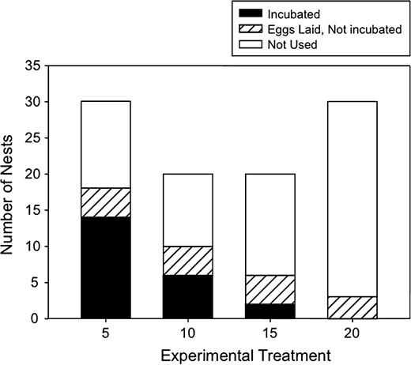

[Open in new tab](https://academic.oup.com/view-large/figure/85851981/behecoarq055f01_lw.jpeg)Download slide

Types of use by experimental treatment. This figure shows the number of boxes that were not used (no eggs were laid), the number of boxes where an egg was laid, and the number of boxes where female(s) laid an egg in the box and incubated the nest.

[figure not shown]

As a second assessment of the response to the clutch size treatments, we compared visual changes in the arrangement of eggs in the box (covered in shavings or uncovered). All treatments exhibited evidence of having being explored by females; over half of all nests (53 of 100) had eggs covered in shavings at some point. However, we found significant differences among treatments in the degree to which females covered eggs (likelihood ratio χ<sup>2</sup> = 24.65, df = 3, *P* < 0.001). A majority of the 5-egg nests (67%, 20 of 30), 10-egg nests (75%, 15 of 20), and 15-egg nests (65%, 13 of 20) exhibited evidence of covering, but only 17% (5 of 30) of the 20-egg nests showed evidence of egg covering. Post hoc tests revealed that the difference among the 5-, 10-, and 15-egg treatment was not significant when the 20-egg nests were excluded (likelihood ratio χ<sup>2</sup> = 0.57, df = 2, *P* > 0.75).

### Do females modify the number of eggs they lay as a function of the number of eggs in a nest?

The average number of eggs laid in experimental boxes differed significantly among treatments (*F* = 3.37, df = 3, 33, *P* = 0.03). More eggs were laid in the smaller clutch treatments ([Figure 2](https://academic.oup.com/beheco/article/21/4/794/249069)) as the number of eggs per treatment declined in direct relation to the number of experimental eggs in each treatment (mean ± standard error [SE]: 5-egg treatment: 11.4 ± 1.3, *n* = 18; 10-egg treatment: 8.3 ± 1.7, *n* = 10; 15-egg treatment: 5.3 ± 2.2, *n* = 6; and 20-egg treatment: 3.0 ± 3.1, *n* = 3). Linear regression of the number of eggs laid against the number of experimental eggs in each treatment suggests that for each incremental experimental egg, approximately 0.58 fewer eggs were laid by wood duck females (regression equation: 14.23 − 0.58 × No. Eggs in Treatment; *F* = 10.68, df = 1, 35, *P* < 0.003). In contrast, the total number of eggs (i.e., “added” by females plus experimental) did not differ significantly among treatments (*F* = 1.80, df = 3, 33, *P* > 0.15), suggesting that there may be an upper limit to the number of eggs that females will lay in a nest site.

Figure 2

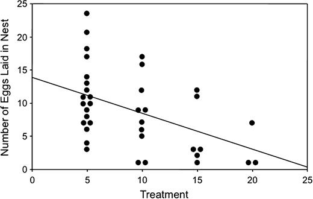

[Open in new tab](https://academic.oup.com/view-large/figure/85851985/behecoarq055f02_lw.jpeg)Download slide

Total clutch sizes by experimental treatment. The *x* axis shows the experimental treatments. The *y* axis shows the total number of eggs laid by females in each box. The regression line illustrates the decline in the number of eggs laid by females in each successive experimental treatment.

[figure not shown]

Although females clearly differed in the number of eggs added to each treatment, the rate at which they did so did not differ among treatments. Egg addition rates (the number of eggs added per day) of the manipulated treatments did not differ significantly (*F* = 0.80, df = 3, 29, *P* > 0.50; mean eggs/day ± SE: 5-egg treatment: 0.39 ± 0.08, 10-egg treatment: 0.48 ± 0.10, 15-egg treatment: 0.29 ± 0.12, and 20-egg treatment: 0.20 ± 0.18). Likewise, the lag time (number of weeks between the start of the experiment and the week the first egg was laid) did not differ significantly among treatments (*F* = 0.80, df = 3, 33, *P* > 0.50; mean lag ± SE: 5-egg treatment: 5.3 weeks ± 1.8, 10-egg treatment: 9.3 ± 2.6, 15-egg treatment: 8.7 ± 2.9, and 20-egg treatment: 4.0 ± 4.5).